# LE NOZZE DI FIGARO - Bayerische Staatsoper

[figure not shown]

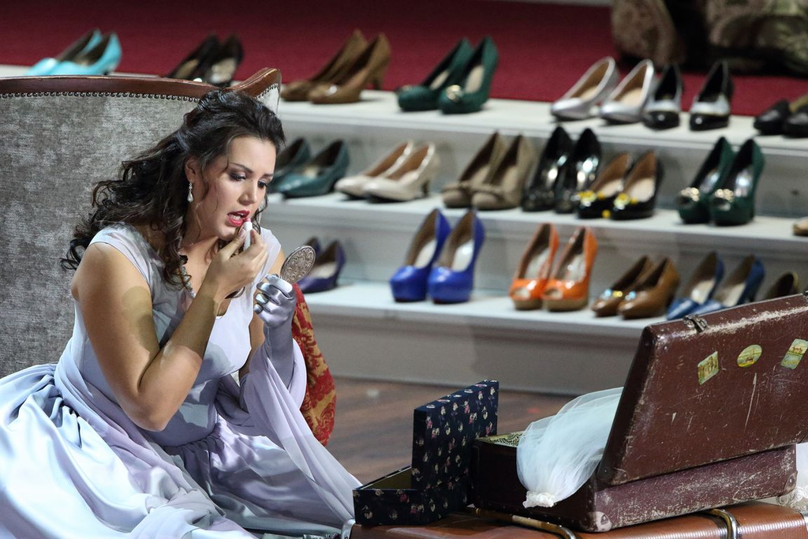

# LE NOZZE DI FIGARO

empfohlen ab 12 Jahren  
Opera buffa in vier Akten - 1786

Komponist Wolfgang Amadeus Mozart. Libretto von Lorenzo da Ponte.  
In italienischer Sprache · Mit Übertiteln in deutscher und englischer Sprache.

Premiere am 26. Oktober 2017

**1. + 2. Akt** (ca. 18.00 - 19.35 Uhr) Pause (ca. 19.35 - 20.10 Uhr) **3. + 4. Akt** (ca. 20.10 - 21.35 Uhr)

[<30 (Info)](https://www.staatsoper.de/u30), U30-Kontingent erschöpft

[Termin merken](https://www.staatsoper.de/stuecke/le-nozze-di-figaro/2020-10-03-1800-12307/calendar.ics)

#BSOfigaro

Bitte beachten Sie, dass in Folge der Corona-Maßnahmen der Orchestergraben vorläufig erweitert wurde. Dies kann zu Sichtbehinderungen und Veränderungen der Kategorisierung im Saalplan führen.

| Musikalische Leitung | [Constantinos Carydis](https://www.staatsoper.de/biographien/carydis-constantinos) |
| --- | --- |
| Inszenierung | [Christof Loy](https://www.staatsoper.de/biographien/loy-christof) |
| Bühne | [Johannes Leiacker](https://www.staatsoper.de/biographien/leiacker-johannes) |
| Puppenbauer | [Axel Bahro](https://www.staatsoper.de/biographien/bahro-axel) |
| Kostüme | [Klaus Bruns](https://www.staatsoper.de/biographien/bruns-klaus) |
| Licht | [Franck Evin](https://www.staatsoper.de/biographien/evin-franck) |
| Dramaturgie | [Daniel Menne](https://www.staatsoper.de/biographien/menne-daniel) |

| Graf Almaviva | [Etienne Dupuis](https://www.staatsoper.de/biographien/dupuis-etienne) |
| --- | --- |
| Gräfin Almaviva | [Golda Schultz](https://www.staatsoper.de/biographien/schultz-golda) |
| Susanna | [Louise Alder](https://www.staatsoper.de/biographien/alder-louise) |
| Figaro | [Alex Esposito](https://www.staatsoper.de/biographien/esposito-alex) |
| Cherubino | [Emily D'Angelo](https://www.staatsoper.de/biographien/dangelo-emily) |
| Marcellina | [Anne Sofie von Otter](https://www.staatsoper.de/biographien/von-otter-anne-sofie) |
| Bartolo | [Peter Rose](https://www.staatsoper.de/biographien/rose-peter) |
| Basilio | [Timothy Oliver](https://www.staatsoper.de/biographien/oliver-timothy) |
| Don Curzio | [Dean Power](https://www.staatsoper.de/biographien/power-dean) |
| Barbarina | [Evgeniya Sotnikova](https://www.staatsoper.de/biographien/sotnikova-evgeniya) |
| Antonio | [Karel Martin Ludvik](https://www.staatsoper.de/biographien/ludvik-karel-martin) |
| Mädchen | [Daria Proszek](https://www.staatsoper.de/biographien/proszek-daria) [Juliana Zara](https://www.staatsoper.de/biographien/zara-juliana) |
| Puppenspieler | [Lorenz Bahro](https://www.staatsoper.de/biographien/bahro-lorenz) [Thomas Schwendemann](https://www.staatsoper.de/biographien/schwendemann-thomas) |

| Bayerisches Staatsorchester |
| --- |
| Bayerischer Staatsopernchor |

[Download Besetzungszettel (PDF)](https://www.staatsoper.de/)

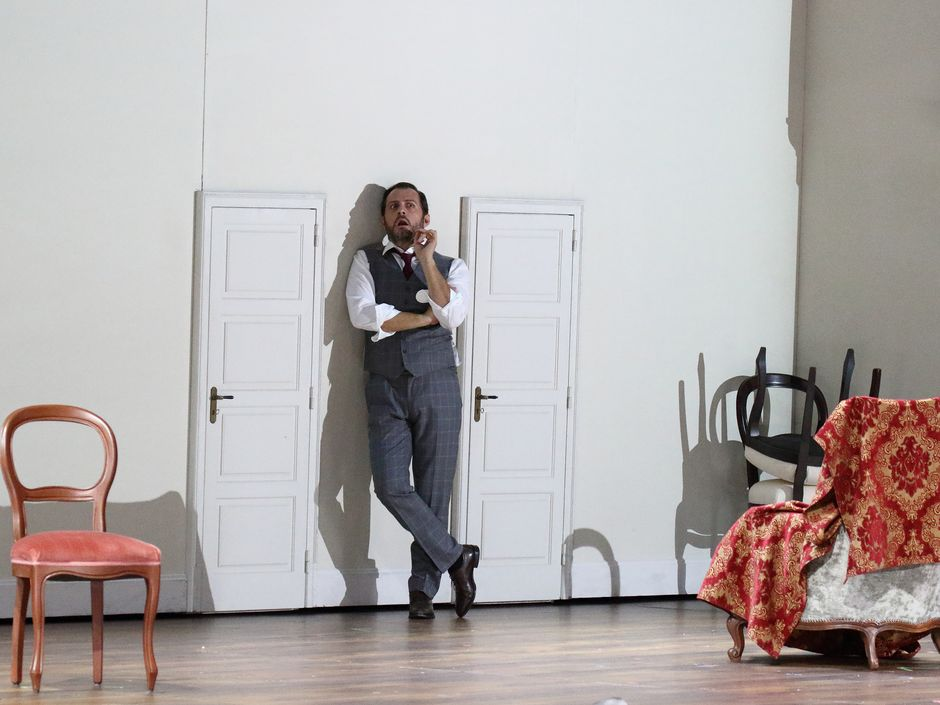

Le Nozze di Figaro: Alex Esposito (Figaro)

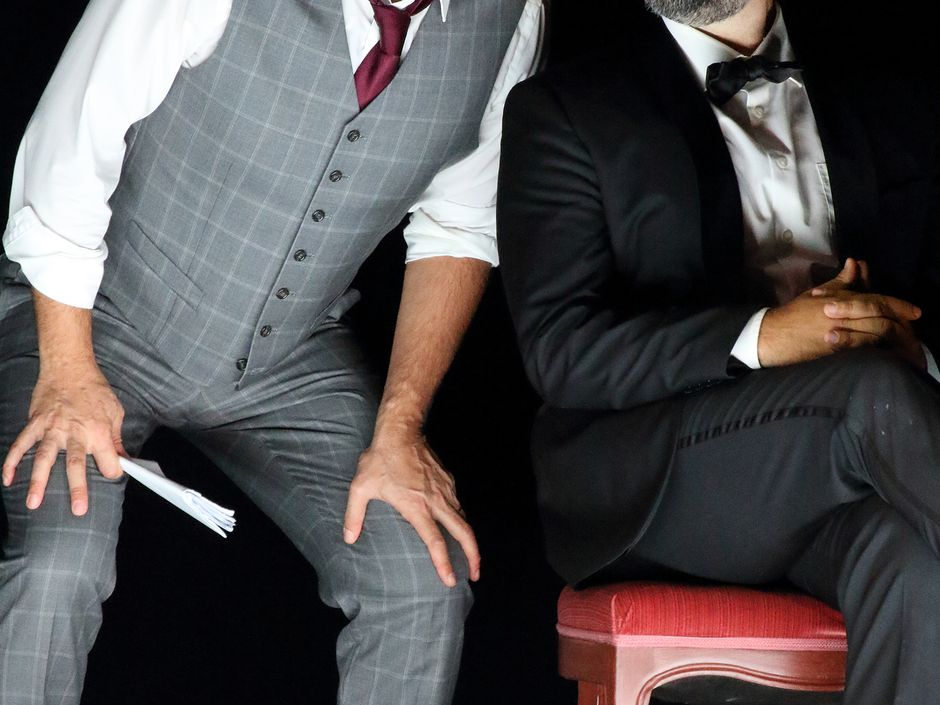

Le Nozze di Figaro: Alex Esposito (Figaro), Etienne Dupuis (Graf Almaviva)

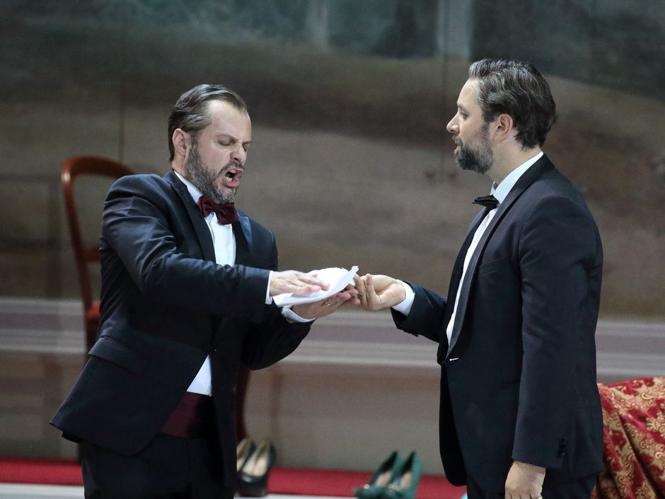

Le Nozze di Figaro: Alex Esposito (Figaro), Etienne Dupuis (Graf Almaviva)

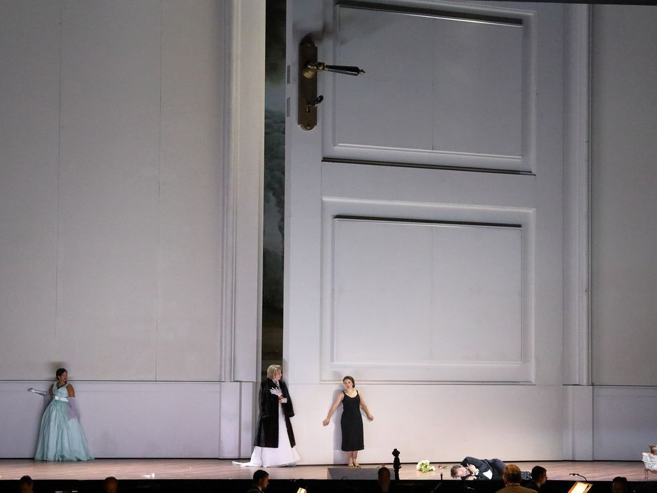

Le Nozze di Figaro: Golda Schultz (Gräfin Almaviva), Anne Sofie von Otter (Marcellina), Louise Alder (Susanna), Etienne Dupuis (Graf Almaviva)

Zugehörige Produkte im Opern ShopAkkordeon umschalten

Le nozze di Figaro (Plakat)

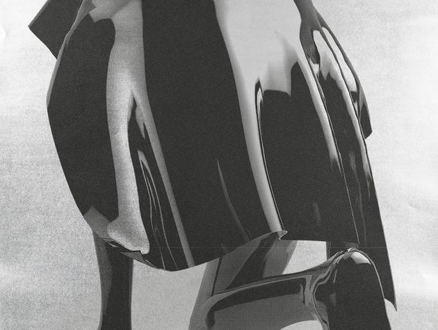

Le nozze di Figaro (Programm)

[figure not shown]

Videos zur ProduktionAkkordeon umschalten

LE NOZZE DI FIGARO: Trailer

[video not shown]

LE NOZZE DI FIGARO: „Abendempfindung“

[video not shown]

LE NOZZE DI FIGARO: „Porgi amor ...“

[video not shown]

Audiofeatures zur ProduktionAkkordeon umschalten

## Le nozze di Figaor: Podcast

Le nozze di Figaor: Podcast

[interactive chart not shown]

## Vergangene Vorstellungen

So 20.03.22

## LE NOZZE DI FIGARO

Wolfgang Amadeus Mozart  
16.00 Uhr, Nationaltheater

Oper

Sa 19.03.22

## LE NOZZE DI FIGARO

Wolfgang Amadeus Mozart  
19.00 Uhr, Nationaltheater

Oper

Di 15.03.22

## LE NOZZE DI FIGARO

Wolfgang Amadeus Mozart  
19.00 Uhr, Nationaltheater

Oper

Fr 11.03.22

## LE NOZZE DI FIGARO

Wolfgang Amadeus Mozart  
19.00 Uhr, Nationaltheater

Oper

Mi 09.03.22

## LE NOZZE DI FIGARO

Wolfgang Amadeus Mozart  
19.00 Uhr, Nationaltheater

Oper

So 18.07.21

## Verschoben: LE NOZZE DI FIGARO

Wolfgang Amadeus Mozart  
18.00 Uhr, Nationaltheater

Oper

Fr 16.07.21

## LE NOZZE DI FIGARO

Wolfgang Amadeus Mozart  
19.00 Uhr, Nationaltheater

Oper

Mi 14.07.21

## LE NOZZE DI FIGARO

Wolfgang Amadeus Mozart  
19.00 Uhr, Nationaltheater

Oper

Sa 03.10.20

## LE NOZZE DI FIGARO

Wolfgang Amadeus Mozart  
18.00 Uhr, Nationaltheater

Oper

Mo 28.09.20

## LE NOZZE DI FIGARO

Wolfgang Amadeus Mozart  
19.00 Uhr, Nationaltheater

Oper

Fr 25.09.20

## LE NOZZE DI FIGARO

Wolfgang Amadeus Mozart  
19.00 Uhr, Nationaltheater

Oper

Mi 23.09.20

## LE NOZZE DI FIGARO

Wolfgang Amadeus Mozart  
19.00 Uhr, Nationaltheater

Oper

So 07.07.19

## LE NOZZE DI FIGARO

Wolfgang Amadeus Mozart  
18.00 Uhr, Nationaltheater

Oper

Fr 05.07.19

## LE NOZZE DI FIGARO

Wolfgang Amadeus Mozart  
18.00 Uhr, Nationaltheater

Oper

Fr 28.09.18

## LE NOZZE DI FIGARO

Wolfgang Amadeus Mozart  
18.00 Uhr, Nationaltheater

Oper

Mi 26.09.18

## LE NOZZE DI FIGARO

Wolfgang Amadeus Mozart  
18.00 Uhr, Nationaltheater

Oper

Sa 22.09.18

## LE NOZZE DI FIGARO

Wolfgang Amadeus Mozart  
18.00 Uhr, Nationaltheater

Oper

Di 17.07.18

## LE NOZZE DI FIGARO

Wolfgang Amadeus Mozart  
18.00 Uhr, Nationaltheater

Oper

So 15.07.18

## LE NOZZE DI FIGARO

Wolfgang Amadeus Mozart  
19.00 Uhr, Nationaltheater

Oper

Fr 10.11.17

## LE NOZZE DI FIGARO

Wolfgang Amadeus Mozart  
19.00 Uhr, Nationaltheater

Oper

Di 07.11.17

## LE NOZZE DI FIGARO

Wolfgang Amadeus Mozart  
19.00 Uhr, Nationaltheater

Oper

Sa 04.11.17

## LE NOZZE DI FIGARO

Wolfgang Amadeus Mozart  
19.00 Uhr, Nationaltheater

Oper

Di 31.10.17

## LE NOZZE DI FIGARO

Wolfgang Amadeus Mozart  
17.00 Uhr, Nationaltheater

Oper

Sa 28.10.17

## LE NOZZE DI FIGARO

Wolfgang Amadeus Mozart  
18.00 Uhr, Nationaltheater

Oper

Do 26.10.17

## LE NOZZE DI FIGARO

Wolfgang Amadeus Mozart  
18.00 Uhr, Nationaltheater

Oper

Mi 07.12.22

## LOHENGRIN

Richard Wagner  
18.00 Uhr, Nationaltheater  
Abo-Serie 45

Preise O , € 218 /190 /- /- /- /- /- /15

Oper

[Tickets](https://tickets.staatstheater.bayern/bso.webshop/webticket/shop?language=de&event=34957)

[Termin merken](https://www.staatsoper.de/stuecke/lohengrin/2022-12-07-1800-13240/calendar.ics)

Fr 09.12.22

## SPRING DOCH

Gordon Kampe  
14.00 Uhr, Rennert-Saal  
PREMIERE!

Preise PG20 , € 20

KIND&CO

[Tickets](https://tickets.staatstheater.bayern/bso.webshop/webticket/shop?language=de&event=35234)

[Termin merken](https://www.staatsoper.de/stuecke/spring-doch/2022-12-09-1400-13491/calendar.ics)

Fr 09.12.22

## Kindereinführung - HÄNSEL UND GRETEL

17.15 Uhr, Königssaal im Nationaltheater

Preise PG3

KIND&CO

ausverkauftausverk.

Fr 09.12.22

## HÄNSEL UND GRETEL

Engelbert Humperdinck  
18.00 Uhr, Nationaltheater  
<30, Familienvorstellung

Preise I , € 100 /88 /73 /56 /40 /25 /12 /9

Oper

[Tickets](https://tickets.staatstheater.bayern/bso.webshop/webticket/shop?language=de&event=34898)

[Termin merken](https://www.staatsoper.de/stuecke/haensel-und-gretel/2022-12-09-1800-13241/calendar.ics)

Sa 10.12.22

## Kindereinführung - HÄNSEL UND GRETEL

10.15 Uhr, Königssaal im Nationaltheater

Preise PG3

KIND&CO

ausverkauftausverk.

Sa 10.12.22

## HÄNSEL UND GRETEL

Engelbert Humperdinck  
11.00 Uhr, Nationaltheater  
Familienvorstellung

Preise H , € 88 /77 /63 /50 /35 /23 /11 /8

Oper

[Tickets](https://tickets.staatstheater.bayern/bso.webshop/webticket/shop?language=de&event=34900)

[Termin merken](https://www.staatsoper.de/stuecke/haensel-und-gretel/2022-12-10-1100-13242/calendar.ics)

Sa 10.12.22

## Kindereinführung - HÄNSEL UND GRETEL

17.15 Uhr, Königssaal im Nationaltheater

Preise PG3

KIND&CO

ausverkauftausverk.

Sa 10.12.22

## HÄNSEL UND GRETEL

Engelbert Humperdinck  
18.00 Uhr, Nationaltheater  
Familienvorstellung, <30

Preise I , € 100 /88 /73 /56 /40 /25 /12 /9

Oper

[Tickets](https://tickets.staatstheater.bayern/bso.webshop/webticket/shop?language=de&event=34899)

[Termin merken](https://www.staatsoper.de/stuecke/haensel-und-gretel/2022-12-10-1800-13243/calendar.ics)

Sa 10.12.22

## Advents-Benefizkonzert

19.00 Uhr, Cuvilliés-Theater

Konzert

[Tickets](https://abk.bmw-veranstaltung.de/ticketbestellung)

Sa 10.12.22

## Weihnachten mit OperaBrass: A WINTER'S TALE

20.00 Uhr, St. Michael  
<30

Preise PG20 , € 20 /15

Konzert

[Tickets](https://tickets.staatstheater.bayern/bso.webshop/webticket/shop?language=de&event=35035)

[Termin merken](https://www.staatsoper.de/stuecke/weihnachten-mit-operabrass/2022-12-10-2000-13594/calendar.ics)

So 11.12.22

## SPRING DOCH

Gordon Kampe  
11.00 Uhr, Rennert-Saal

Preise PG20

KIND&CO

ausverkauftausverk.

So 11.12.22

## LOHENGRIN

Richard Wagner  
17.00 Uhr, Nationaltheater  
Abo-Serie 11

Preise M , € - /- /- /- /- /- /- /14

Oper

[Tickets](https://tickets.staatstheater.bayern/bso.webshop/webticket/shop?language=de&event=34958)

[Termin merken](https://www.staatsoper.de/stuecke/lohengrin/2022-12-11-1700-13244/calendar.ics)

So 11.12.22

## Porträtkonzert des Opernstudios

18.00 Uhr, Künstlerhaus  
<30

Preise PG20 , € 20

Konzert

[Tickets](https://tickets.staatstheater.bayern/bso.webshop/webticket/shop?language=de&event=35040)

[Termin merken](https://www.staatsoper.de/stuecke/portraetkonzert-des-opernstudios/2022-12-11-1800-13245/calendar.ics)

Mo 12.12.22

## SPRING DOCH

Gordon Kampe  
11.00 Uhr, Rennert-Saal  
SCHULE&CO

Preise PG20

KIND&CO

ausverkauftausverk.

Mo 12.12.22

## HÄNSEL UND GRETEL

Engelbert Humperdinck  
19.00 Uhr, Nationaltheater  
Abo-Serie 21, <30

Preise I , € 100 /88 /73 /56 /40 /25 /12 /9

Oper

[Tickets](https://tickets.staatstheater.bayern/bso.webshop/webticket/shop?language=de&event=34901)

[Termin merken](https://www.staatsoper.de/stuecke/haensel-und-gretel/2022-12-12-1900-13246/calendar.ics)

Di 13.12.22

## SPRING DOCH

Gordon Kampe  
11.00 Uhr, Rennert-Saal  
SCHULE&CO

Preise PG20

KIND&CO

ausverkauftausverk.

Di 13.12.22

## SPRING DOCH

Gordon Kampe  
17.00 Uhr, Rennert-Saal

Preise PG20 , € 20

KIND&CO

[Tickets](https://tickets.staatstheater.bayern/bso.webshop/webticket/shop?language=de&event=35238)

[Termin merken](https://www.staatsoper.de/stuecke/spring-doch/2022-12-13-1700-13495/calendar.ics)

Mi 14.12.22

## LOHENGRIN

Richard Wagner  
18.00 Uhr, Nationaltheater  
Abo-Serie 52

Preise M , € - /- /- /- /- /- /- /14

Oper

[Tickets](https://tickets.staatstheater.bayern/bso.webshop/webticket/shop?language=de&event=34959)

[Termin merken](https://www.staatsoper.de/stuecke/lohengrin/2022-12-14-1800-13247/calendar.ics)

Mi 14.12.22

## BEYOND HOLY NIGHT: Weihnachtskonzert

20.00 Uhr, Brainlab  
<30

Preise PG20 , € 20

Konzert

[Tickets](https://tickets.staatstheater.bayern/bso.webshop/webticket/shop?language=de&event=36257)

[Termin merken](https://www.staatsoper.de/stuecke/weihnachtskonzert-beyond-holy-night/2022-12-14-2000-13840/calendar.ics)

Do 15.12.22

## SPRING DOCH

Gordon Kampe  
11.00 Uhr, Rennert-Saal  
SCHULE&CO

Preise PG20

KIND&CO

ausverkauftausverk.

Fr 16.12.22

## SPRING DOCH

Gordon Kampe  
15.00 Uhr, Rennert-Saal

Preise PG20 , € 20

KIND&CO

[Tickets](https://tickets.staatstheater.bayern/bso.webshop/webticket/shop?language=de&event=35240)

[Termin merken](https://www.staatsoper.de/stuecke/spring-doch/2022-12-16-1500-13497/calendar.ics)

Sa 17.12.22

## LOHENGRIN

Richard Wagner  
17.00 Uhr, Nationaltheater  
Abo-Serie 61

Preise M , € - /- /- /- /- /- /- /14

Oper

[Tickets](https://tickets.staatstheater.bayern/bso.webshop/webticket/shop?language=de&event=34960)

[Termin merken](https://www.staatsoper.de/stuecke/lohengrin/2022-12-17-1700-13248/calendar.ics)

So 18.12.22

## EINFÜHRUNGSMATINEE ZU TSCHAIKOWSKI-OUVERTÜREN

11.00 Uhr, Nationaltheater

Preise PG10 , € 10

Ballett

[Tickets](https://tickets.staatstheater.bayern/bso.webshop/webticket/shop?language=de&event=34989)

[Termin merken](https://www.staatsoper.de/stuecke/einfuehrungsmatinee-zu-tschaikowski-ouvertueren/18-12-2022-1100-13601/calendar.ics)

So 18.12.22

## AUSVERKAUFT: Einführungsworkshop - CINDERELLA

14.00 Uhr, Ballett-Probenhaus Platzl 7  
Einführungsworkshops

KIND&CO

[Tickets](https://staatsoper.de/service/karten-spieloper/spielballett)

So 18.12.22

## Kindereinführung - HÄNSEL UND GRETEL

16.15 Uhr, Königssaal im Nationaltheater

Preise PG3

KIND&CO

ausverkauftausverk.

So 18.12.22

## HÄNSEL UND GRETEL

Engelbert Humperdinck  
17.00 Uhr, Nationaltheater  
Familienvorstellung

Preise I , € 100 /88 /73 /56 /40 /25 /12 /9

Oper

[Tickets](https://tickets.staatstheater.bayern/bso.webshop/webticket/shop?language=de&event=34902)

[Termin merken](https://www.staatsoper.de/stuecke/haensel-und-gretel/2022-12-18-1700-13250/calendar.ics)

Mo 19.12.22

## LA BOHÈME

Giacomo Puccini  
19.00 Uhr, Nationaltheater  
<30

Preise K , € 132 /- /- /- /- /- /- /10

Oper

[Tickets](https://tickets.staatstheater.bayern/bso.webshop/webticket/shop?language=de&event=34931)

[Termin merken](https://www.staatsoper.de/stuecke/la-boheme/2022-12-19-1900-13251/calendar.ics)

Mi 21.12.22

## LOHENGRIN

Richard Wagner  
17.00 Uhr, Nationaltheater  
Abo-Serie 32

Preise M , € - /- /- /- /- /- /- /14

Oper

[Tickets](https://tickets.staatstheater.bayern/bso.webshop/webticket/shop?language=de&event=34961)

[Termin merken](https://www.staatsoper.de/stuecke/lohengrin/2022-12-21-1700-13252/calendar.ics)

Fr 23.12.22

## TSCHAIKOWSKI-OUVERTÜREN

Alexei Ratmansky  
19.30 Uhr, Nationaltheater  
PREMIERE!  
Abo-Serie 44

Preise K , € 132 /115 /95 /74 /52 /30 /14 /10

Ballett

[Tickets](https://tickets.staatstheater.bayern/bso.webshop/webticket/shop?language=de&event=35066)

[Termin merken](https://www.staatsoper.de/stuecke/tschaikowski-ouvertueren/2022-12-23-1930-13253/calendar.ics)

So 25.12.22

## Kindereinführung - LA BOHÈME

16.15 Uhr, Königssaal im Nationaltheater

Preise PG3

KIND&CO

ausverkauftausverk.

So 25.12.22

## LA BOHÈME

Giacomo Puccini  
17.00 Uhr, Nationaltheater  
Familienvorstellung

Preise K , € 132 /115 /- /- /- /- /14 /10

Oper

[Tickets](https://tickets.staatstheater.bayern/bso.webshop/webticket/shop?language=de&event=34932)

[Termin merken](https://www.staatsoper.de/stuecke/la-boheme/2022-12-25-1700-13254/calendar.ics)

Mo 26.12.22

## TSCHAIKOWSKI-OUVERTÜREN

Alexei Ratmansky  
15.00 Uhr, Nationaltheater  
Familienvorstellung

Preise I , € 100 /88 /73 /56 /40 /25 /12 /9

Ballett

[Tickets](https://tickets.staatstheater.bayern/bso.webshop/webticket/shop?language=de&event=35068)

[Termin merken](https://www.staatsoper.de/stuecke/tschaikowski-ouvertueren/2022-12-26-1500-13255/calendar.ics)

Mo 26.12.22

## TSCHAIKOWSKI-OUVERTÜREN

Alexei Ratmansky  
19.30 Uhr, Nationaltheater  
Abo-Serie 45

Preise I , € 100 /88 /73 /56 /40 /25 /12 /9

Ballett

[Tickets](https://tickets.staatstheater.bayern/bso.webshop/webticket/shop?language=de&event=35067)

[Termin merken](https://www.staatsoper.de/stuecke/tschaikowski-ouvertueren/2022-12-26-1930-13256/calendar.ics)

Di 27.12.22

## TSCHAIKOWSKI-OUVERTÜREN

Alexei Ratmansky  
19.30 Uhr, Nationaltheater  
<30

Preise I , € 100 /88 /73 /56 /40 /25 /12 /9

Ballett

[Tickets](https://tickets.staatstheater.bayern/bso.webshop/webticket/shop?language=de&event=35069)

[Termin merken](https://www.staatsoper.de/stuecke/tschaikowski-ouvertueren/2022-12-27-1930-13257/calendar.ics)

Mi 28.12.22

## LA BOHÈME

Giacomo Puccini  
19.30 Uhr, Nationaltheater

Preise K , € 132 /115 /- /- /52 /- /14 /10

Oper

[Tickets](https://tickets.staatstheater.bayern/bso.webshop/webticket/shop?language=de&event=34933)

[Termin merken](https://www.staatsoper.de/stuecke/la-boheme/2022-12-28-1930-13258/calendar.ics)

Do 29.12.22

## Kindereinführung - DIE VERKAUFTE BRAUT

18.15 Uhr, Königssaal im Nationaltheater

Preise PG3 , € 3

KIND&CO

[Tickets](https://tickets.staatstheater.bayern/bso.webshop/webticket/shop?language=de&event=35259)

[Termin merken](https://www.staatsoper.de/stuecke/kindereinfuehrung/2022-12-29-1815-13533/calendar.ics)

Do 29.12.22

## DIE VERKAUFTE BRAUT

Bedřich Smetana  
19.00 Uhr, Nationaltheater  
<30, Familienvorstellung

Preise K , € 132 /115 /95 /74 /52 /30 /14 /10

Oper

[Tickets](https://tickets.staatstheater.bayern/bso.webshop/webticket/shop?language=de&event=35251)

[Termin merken](https://www.staatsoper.de/stuecke/die-verkaufte-braut/2022-12-29-1900-13259/calendar.ics)

Fr 30.12.22

## CINDERELLA

Christopher Wheeldon  
19.30 Uhr, Nationaltheater  
Abo-Serie 42

Preise I , € - /- /- /- /- /- /12 /9

Ballett

[Tickets](https://tickets.staatstheater.bayern/bso.webshop/webticket/shop?language=de&event=34803)

[Termin merken](https://www.staatsoper.de/stuecke/cinderella/2022-12-30-1930-13260/calendar.ics)

Sa 31.12.22

## DIE FLEDERMAUS

Johann Strauß  
18.00 Uhr, Nationaltheater

Preise O , € 218 /190 /162 /130 /96 /66 /18 /15

Oper

[Tickets](https://tickets.staatstheater.bayern/bso.webshop/webticket/shop?language=de&event=34843)

[Termin merken](https://www.staatsoper.de/stuecke/die-fledermaus/2022-12-31-1800-13261/calendar.ics)